# Topics in Advanced Statistics Group Assignment March 2017

Bas Dunn [434067] Marnix Koops [432409] Eline Tjeng [432541]

## **Question 1:**

The first part concerns the implementation of the Deterministic MCD (DetMCD) algorithm.  
Click “Code” button on the right to show or hide the script.

```r
# --------------------------------------------------------------------
# Author:
# * Group 7
# B.C. Dunn     434067
# M. Koops      432409
# E.R. Tjeng    432409
# --------------------------------------------------------------------

## Use this code skeleton to implement the deterministic MCD and the resulting
## robust regression estimator.  Please submit your implementation together
## with your report.

## IMPORTANT: Please do not change any function names and make sure that you
##            use the correct input and output as specified for each function.
##            This will allow me to do some automated testing of your
##            implementations.  Of course you can define any additional
##            functions you may need.

library(robustbase)
library(MTS)
library(ggplot2)

# correlation matrix based on the hyperbolic tangent
corHT <- function(z) {

  # Transform to hyperbolic tangent
  z.tiddle = apply(z,
                   MARGIN = 2,
                   function(zcol){
                     tanh(zcol)
                   })
  # Calculate normal pearson correlation
  cor.z.tiddle = cor(z.tiddle, method = "pearson")

  return(cor.z.tiddle)
}

# spearman correlation matrix
corSpearman <- function(z) {
  # The following code does the same as cor(z, method="spearman")

  # Transform to rank
  z.rank = apply(z,
                 MARGIN = 2,
                 function(zcol){rank(zcol)}
  )

  # Calculate normal pearson correlation
  cor.z.rank = cor(z.rank, method = "pearson")

  return(cor.z.rank)
}

# correlation matrix based on normal scores of the ranks
corNSR <- function(z) {

  # Transform to normal scores of rank
  z.rank.normal = apply(z,
                        MARGIN = 2,
                        function(zcol){
                          step1 = (rank(zcol) - (1/3)) / (nrow(z)+(1/3))
                          qnorm(step1)
                        }
  )

  # Calculate normal pearson correlation
  cor.z.rank.normal = cor(z.rank.normal, method = "pearson")

  return(cor.z.rank.normal)
}

# modified spatial sign covariance matrix
covMSS <- function(z) {

  # Transform to normal scores of rank
  z.spatial = apply(z,
                    MARGIN = 1,
                    function(zrow){
                      zrow / sqrt(sum((zrow)^2))
                    })

  # Calculate the correlation
  cor.z.spatial = (1/nrow(z)) * z.spatial %*% t(z.spatial)

  return(cor.z.spatial)
}

# covariance matrix based on first step of BACON
covBACON1 <- function(z) {
  z.norm = apply(z, MARGIN = 1, function(zrow){sqrt(sum(zrow^2))})

  z.ordered = z[order(z.norm),]

  z.selection = z.ordered[1:ceiling(nrow(z)/2),]

  return(cov(z.selection))
}

# raw OGK estimator of the covariance matrix with median and Qn
# Hint: have a look at function covOGK() in package robustbase
rawCovOGK <- function(z) {

  D = diag(apply(z, MARGIN = 2, function(zj){Qn(zj)}))
  zscaled = t( apply(z, MARGIN=1, function(zi){solve(D, diag(nrow(D)))%*%zi} ) )
  u = matrix(NA, ncol(zscaled), ncol(zscaled))
  for(j in 1:ncol(zscaled)){
    for(k in 1:ncol(zscaled)){
      u[j,k] = (1/4) * ( Qn(zscaled[,j] + zscaled[,k])^2 - Qn(zscaled[,j] - zscaled[,k])^2 )
    }
  }
  E = eigen(u)$vectors
  V = zscaled %*% E
  L = diag( apply(V, MARGIN = 2, function(Vj){ Qn(Vj)^2 } ) )
  sigm =  E %*% L %*% t(E)
  rawsigm = D %*% sigm %*% t(D)

  return(rawsigm)

}







## Main function for deterministic MCD algorithm

# Input:
# x ... data matrix
# h ... subset size
# anything else you need

# Output
# A list with the following components:
# center ....... mean of the reweighted estimator
# cov .......... covariance matrix of the reweighted estimator
# weights ...... binary weights of the observations used for the reweighted
#                estimator (0 if outlier, 1 if used for estimation)
# raw.center ... mean of the raw estimator
# raw.cov ...... covariance matrix of the raw estimator
# best ......... indices of the observations in the best subset found by the
#                raw estimator
# any other output you want to return

covDetMCD <- function(x, h, ...) {

  # Standardize the data
  x.stand = apply(x, MARGIN = 2, function(xcol){ ( xcol-median(xcol) ) / Qn(xcol)})

  # Generate initial functions to calculate sigma
  init.functions = list(corHT=corHT, corSpearman=corSpearman, corNSR=corNSR, covMSS=covMSS, covBACON1=covBACON1, rawCovOGK=rawCovOGK)

  # Calculate initial six sigma estimates S
  S = lapply(init.functions, function(f){f(x.stand)})

  # Step 1:
  # Calculate eigenvectors of S
  E = lapply(S, function(Sk){eigen(Sk)$vectors})

  # Calculate V
  V = lapply(E, function(Ek){x.stand%*%Ek})

  # Step 2:
  # Calculate L
  L = lapply(V,
             function(Vk){

               Qn2 = apply(Vk, MARGIN = 2,
                           function(Vkp){
                             Qn(Vkp)^2
                           })

               diag(Qn2)
             })

  # Calculate covariance estimates
  Sig_estimates = lapply(1:length(L),
                         function(lindex){
                           E[[lindex]] %*% L[[lindex]] %*% t(E[[lindex]])
                         })

  # Get square root of sigma
  sqrt_sig_estimates = lapply(1:length(L),
                              function(lindex){
                                msqrt(Sig_estimates[[lindex]])$mtxsqrt
                              })

  # Get inverted square root of sigma
  invsqrt_sig_estimates = lapply(1:length(L),
                                 function(lindex){
                                   msqrt(Sig_estimates[[lindex]])$invsqrt
                                 })

  # Calculate mu using sigma estimates
  mu = lapply(1:length(L),
              function(lindex){

                # Calculate the mu estimate based on the sig estimates
                sqrt_sig_estimates[[lindex]] %*% ( colMedians(x.stand %*% invsqrt_sig_estimates[[lindex]]) )

              })

  # Calculate statistical distances based on sig_estimates and mu
  distances = lapply(1:length(L),
                     function(lindex){
```

```r
                       # Calculate the mahalanobis distance
                       mahalanobis(x.stand,center = mu[[lindex]], cov=Sig_estimates[[lindex]])

                     }
  )

  # Select the 2/n observations per estimator based on the smallest stat.distance
  h0 =  lapply(1:length(L),
               function(lindex){

                 # Take only observations which rank is smaller or equal than half the set size
                 x[rank(distances[[lindex]])<=ceiling(nrow(x.stand)/2),]

               }
  )
  # Calculate the sigma estimates again based on only the h0 subsets
  h0.sig.estimates = lapply(1:length(L),
                            function(lindex){

                              #init.functions[[lindex]](h0[[lindex]])
                              cov(h0[[lindex]])

                            })

  # Calculate the mu based on the new sigma estimates
  h0.mu.estimates = lapply(1:length(L),
                           function(lindex){

                             # Calculate the means of the h0 sets
                             colMeans(h0[[lindex]])

                           })

  #$ Calculate the statistical distances per estimator based on the estimates above
  h0.distances = lapply(1:length(L),
                        function(lindex){

                          # Calculate the mahalanobis distance for each h0 set.
                          mahalanobis(x,center = h0.mu.estimates[[lindex]], cov=h0.sig.estimates[[lindex]])

                        })

  # Create places to save data for the six initial starts of the c-step
  raw.center.saved = list(corHT=NA, corSpearman=NA, corNSR=NA, covMSS=NA, covBACON1=NA, rawCovOGK=NA)
  raw.cov.saved = list(corHT=NA, corSpearman=NA, corNSR=NA, covMSS=NA, covBACON1=NA, rawCovOGK=NA)
  best.saved = list(corHT=NA, corSpearman=NA, corNSR=NA, covMSS=NA, covBACON1=NA, rawCovOGK=NA)
  det.saved = list(corHT=NA, corSpearman=NA, corNSR=NA, covMSS=NA, covBACON1=NA, rawCovOGK=NA)
  distance.saved = list(corHT=NA, corSpearman=NA, corNSR=NA, covMSS=NA, covBACON1=NA, rawCovOGK=NA)

  # Do c-step algorithm for all six initial starts
  for (lindex in 1:length(h0.distances)){

    # determine initial weights based on previous
    weights = (rank(h0.distances[[lindex]])<=h)

    # Get subset of x
    subset.x = x[weights,]

    # Calculate mean and cov
    subset.mean = colMeans(subset.x)
    subset.cov = cov(subset.x)

    # Calculate determinant of cov
    det.prev= Inf
    det.current = det(subset.cov)

    while(det.current < det.prev){

      # COmpute the mah. distances
      mah.dist = mahalanobis(x, center=subset.mean, cov=subset.cov)

      # Determine the TRUE/FALSE weights
      weights = (rank(mah.dist)<=h)

      # Get new subset of x
      subset.x = x[weights,]

      # Calculate new mean and cov
      subset.mean = colMeans(subset.x)
      subset.cov = cov(subset.x)

      # Shift saved determinants
      det.prev = det.current
      det.current = det(subset.cov)

      # Print progress
      print(paste("for estimator",lindex,"from",round(det.prev,4),"to",round(det.current,4)))


    }

    # Save results for this estimator
    raw.center.saved[[lindex]] = subset.mean
    raw.cov.saved[[lindex]] = subset.cov
    best.saved[[lindex]] = order(mah.dist)[1:h]
    det.saved[[lindex]] = det.current
    distance.saved[[lindex]] =  mahalanobis(x, center=subset.mean, cov=subset.cov)

  }

  # Determine the results set which is the best (minimal det(cov))
  best.result.ID = which.min(sapply(1:length(det.saved),
                                    function(lindex){
                                      det.saved[[lindex]]
                                    }))
  # Print which function had the best initial start
  print(paste("Winning initialstart function:",names(det.saved)[best.result.ID]))


  # A list with the following components:
  # center ....... mean of the reweighted estimator
  # cov .......... covariance matrix of the reweighted estimator
  # weights ...... binary weights of the observations used for the reweighted
  #                estimator (0 if outlier, 1 if used for estimation)
  # raw.center ... mean of the raw estimator
  # raw.cov ...... covariance matrix of the raw estimator
  # best ......... indices of the observations in the best subset found by the
  #                raw estimator


  # Create end results
  r.raw.center = raw.center.saved[[best.result.ID]]
  r.raw.cov = raw.cov.saved[[best.result.ID]]
  r.best = best.saved[[best.result.ID]]
  # Calculate new weights based on chisq criterium
  r.weights = ( distance.saved[[best.result.ID]] <=  sqrt(qchisq(p=0.975, df = ncol(x))) )
  # Calculate final center and cov estimate based on new weights
  r.center = colMeans(x[r.weights,])
  r.cov = cov(x[r.weights,])

  return(list(center=r.center, cov=r.cov, weights=1*r.weights, raw.center=r.raw.center, raw.cov=r.raw.cov, best=r.best))

}


## Function for regression based on the deterministic MCD

# Input:
# x ... matrix of explanatory variables
# y ... response variable
# h ... subset size
# anything else you need

# Output
# A list with the following components:
# coefficients .... estimated regression coefficients based on the reweighted
#                   deterministic MCD covariance matrix
# fitted.values ... fitted values for all observations in the data
# residuals ....... residuals for all observations in the data
# MCD ............. R object for the deterministic MCD (entire output from
#                   function covDetMCD())
# any other output you want to return

lmDetMDC <- function(x, y, h, ...) {

  binded.x.y = cbind(y,x)

  covdet.res = covDetMCD(x=binded.x.y, h=h)

  sig = covdet.res$cov
  mu = covdet.res$center

  beta = solve(sig[2:nrow(sig),2:nrow(sig)]) %*% sig[2:nrow(sig), 1]
  alpha = mu[1] - t(mu[2:nrow(sig)]) %*% beta

  if(is.vector(x)){
    fitted.v = alpha + x * beta
  }
  else{
    fitted.v = alpha*rep(1,nrow(x)) +  x %*% beta
  }

  resid = y - fitted.v

  return(list(coefficients=c(alpha,beta), fitted.values=fitted.v, residuals=resid, covDetMCDres=covdet.res))
```

```r
}


set.seed(20172017)
x=seq(0.1,10,0.1) + rnorm(100)
y=25+3*x + rnorm(100,0,5)
y = y + rep(c(1,0,0,0,0,0,0,0,0,0),10)*30



lmres = lmDetMDC(x=x,y=y,h=90)
print(lmres)

ggplot() + geom_point(aes(x=x,y=y, colour=as.factor(lmres$covDetMCDres$weights)), size=3) + geom_abline(intercept=lmres$coefficients[1], slope=lmres$coefficients[2], colour="black", size=2) + theme(legend.title=element_blank())

# TEST 2
set.seed(20172017)
x1=sample(1:100)
x2=sample(1:100)

y=25+ 3*x1 -2*x2 + rnorm(100,0,5)

y = y + c(rep(100,10), rep(0,90))

lmres = lmDetMDC(x=cbind(x1,x2),y=y,h=90)
print(lmres$coefficients)

ggplot() + geom_point(aes(x=lmres$fitted.values, y=y, colour=as.factor(1:100 %in% lmres$covDetMCDres$best)), size=3) + geom_abline(intercept=0, slope=1, colour="black", size=2) + theme(legend.title=element_blank())
```

## **Question 2:**

Here we discuss the relation between the Least Trimmed Squares (LTS) and DetMCD estimator and mention some of its (dis)advantages.

The LTS regression estimator is similar to the MCD which is used for covariance estimation. However, the LTS is much less efficient. The MCD selects a subset h out of n observations whose covariance matrix has the lowest determinant. LTS selects a subset h out of n observations whose least squares fit has the smallest sum of squared residuals. The MCD and LTS can only be approximated by algorithms such as the FASTMCD and FASTLTS. These algorithms start by drawing many random subsets. On the contrary, the DetMCD does not initiate with random subsets but uses a set of deterministic initial estimators. A consequence is that the DetMCD is significantly faster in general, especially in lower dimensions ([Hubert et al., 2012](http://www.tandfonline.com/doi/abs/10.1080/10618600.2012.672100)).  
Furthermore, the DetMCD is almost always more robust than FASTMCD and very close to affine equivariant ([Hubert et al., 2012](http://www.tandfonline.com/doi/abs/10.1080/10618600.2012.672100)). Since detMCD is deterministic it is permutation invariant in contrast to the LTS and MCD. However, in a similar way as the DetMCD, a DetLTS algorithm can be constructed which is shown to be also permutation invariant and very close to affine equivariant. The DetMCD and DetLTS are sometimes more robust in case of highly contaminated data ([Verdonck et al., 2013](http://2013.isiproceedings.org/Files/CPS021-P1-A.pdf)).

The second step is identical in the FASTMCD, DetMCD and LTS algorithms. All three methods employ an iteration of concentration steps (C-steps) to obtain improving accuracy. A disadvantage for both the MCD and LTS estimator is that the estimator is not unbiased when a small amount of observations is used. In this case too many observations are wrongly identified as outliers ([Pison, 2002](http://link.springer.com/article/10.1007/s001840200191)). *Table 1* below displays a comparison of the abovementioned methods.

*Table 1: Comparison of Methods*

| Method | Robustness | Efficiency | Permutation_inv | Affine_eq |
| --- | --- | --- | --- | --- |
| **LTS** | High | Very low | No | Yes |
| **DetMCD** | High |  | Yes | Very close |
| **FASTMCD** | High |  | No | Yes |
| **MM-Estimator** | High | High | Very close | Yes |
| **OLS** | Very Low | High if ~N |  |  |

## **Question 3:**

This question covers a simulation to compare behavior of the discussed estimators. Since we have also been discussing the LTS it is included in the simulation as well as the MM, LTS and DetMCD. Again the “Code” button on the right can be clicked to view or hide the script.

```r
# Author:
# Group 7
# B.C. Dunn     434067
# M. Koops      432409
# E.R. Tjeng    432541

rm(list=ls())
library(ggplot2)
source("DeterministicMCD.R") # remember to set working directory to right folder
set.seed(20170325)

# Generate a conteminated dataset
# X                     the original X data
# alpha and beta        the formulas for y
# outlier.distance.X    the distance the outliers should deviate from the center of the x's
# outlier.distance.y    the distance the outliers should deviate from the center of the y's

generate.dataset = function(X=data.frame(x1=sample(1:20),x2=sample(1:20),x3=sample(1:20)),
                            alpha=50,
                            beta=c(-1,4,-6),
                            outlier.deviation.X=c(100,100,100),
                            outlier.deviation.y=100,
                            num.outliers=5,
                            sigma=10){

    # transform the X to a matrix for calculations
    X = as.matrix(X)

    # Generate contaminated X-data.
    #   an outlier is the first "num.outliers' points.
    #   an outlier is the colMeans plus the outlier.deviation.X
    #   + a jitter by a normal distribution with mean 0 and sd 1/10 times the range of the original data
    X[1:num.outliers,] =  matrix(colMeans(X), nrow = num.outliers, ncol = length(colMeans(X)),
                                 byrow = TRUE)  + matrix(outlier.deviation.X,
                                 nrow = num.outliers, ncol = length(outlier.deviation.X),
                                 byrow = TRUE) + apply(X, MARGIN = 2, function(col){
                                 rnorm(n=num.outliers, 0, sd=(max(col)-min(col))/10 ) })

    # Calculate y based on X and the parameters
    y = X %*% beta + alpha + rnorm(n=nrow(X), 0, sigma)

    # Contaminate y
    y[1:num.outliers] = y[1:num.outliers] + outlier.deviation.y

    y = as.matrix(y)

    return(list(X=X,y=y, outliers=1:nrow(X) %in% 1:num.outliers ))

}

results.model.detmcd = list()
results.model.lts = list()
results.model.ols = list()
results.model.mm = list()

# Keep an index to fill the above variables
scenario = 1

# For each scenario do the following
for(num.outliers in c(10,20,30,40)){

  # Make place for the itermediate results
  intermediate.results.model.detmcd = list()
  intermediate.results.model.lts = list()
  intermediate.results.model.ols = list()
  intermediate.results.model.mm = list()

  # Repeat the runs so we can calculate the mean of the estimators and the variance
  for (it in 1:1000){

    # Generate the data and save it
    iteration.data = generate.dataset(X=sample(100), alpha = 100, beta=2,
                                      outlier.deviation.X = 100, outlier.deviation.y = 300,
                                      num.outliers = num.outliers, sigma = 40)

    # Estimate regression parameters

    # DETMCD
    intermediate.results.model.detmcd[[it]] = lmDetMDC(y=iteration.data$y, x=iteration.data$X,
                                                      h=ceiling((nrow(iteration.data$X) +
                                                      ncol(iteration.data$X) + 1)/ 2))
    # LTS
    intermediate.results.model.lts[[it]] = ltsReg(y=iteration.data$y, x=iteration.data$X)
    # OLS
    intermediate.results.model.ols[[it]] = lm(data=data.frame(y=iteration.data$y,
                                                              x=iteration.data$X))
    # MM
    intermediate.results.model.mm[[it]] = lmrob(data=data.frame(y=iteration.data$y,
                                                                x=iteration.data$X))
  }

  # Subtract the coefficients of the intermediate results and save them with the corresponding scenario number

  results.model.detmcd[[scenario]] = t(sapply(1:length(intermediate.results.model.detmcd),
                                              function(it){
                                                intermediate.results.model.detmcd[[it]]$coefficients
                                                }))

  results.model.lts[[scenario]] = t(sapply(1:length(intermediate.results.model.lts),
                                           function(it){
                                             intermediate.results.model.lts[[it]]$coefficients
                                             }))

  results.model.ols[[scenario]] = t(sapply(1:length(intermediate.results.model.ols),
                                           function(it){
                                             intermediate.results.model.ols[[it]]$coefficients
                                             }))

  results.model.mm[[scenario]] = t(sapply(1:length(intermediate.results.model.mm),
                                          function(it){
                                            intermediate.results.model.mm[[it]]$coefficients
                                            }))
 scenario = scenario + 1
}

# Save iteration data for simulation plot
 #save(iteration.data, file = "iteration_data_lev.Rdata")

# Plot some example of the data
ggplot() + geom_point(aes(x=iteration.data$X, y=iteration.data$y)) +
  ggtitle("Example simulation data") +
  labs(x="x", y="y") + geom_abline(intercept=100, slope=2, colour="#00B0F6", linetype="longdash",size=1)

# Calculate the variances of the different estimators for each case
variances = t( sapply(1:length(results.model.detmcd), function(sc) {
  c(detmcdA = var(results.model.detmcd[[sc]][,1]),
    detmcdB = var(results.model.detmcd[[sc]][,2]),
    ltsA = var(results.model.lts[[sc]][,1]),
    ltsB = var(results.model.lts[[sc]][,2]),
    olsA = var(results.model.ols[[sc]][,1]),
    olsB = var(results.model.ols[[sc]][,2]),
    mmA = var(results.model.mm[[sc]][,1]),
    mmB = var(results.model.mm[[sc]][,2]))
  }))

# Save variances results matrix
save(variances, file = "variances_lev.Rdata")

# Plot the variances
ggplot() + geom_line(aes(x=c(10,20,30,40), y=variances[,2]), colour="red", size=1)  +
  geom_line(aes(x=c(10,20,30,40), y=variances[,4]), colour="green", size=1) +
  geom_line(aes(x=c(10,20,30,40), y=variances[,6]), colour="blue", size=1) +
  geom_line(aes(x=c(10,20,30,40), y=variances[,8]), colour="orange", size=1) +
  ggtitle("Variance of beta per estimator") +
  labs(x="# bad leverage outliers", y="Variance of beta")

# Calculate the means
means = t( sapply(1:length(results.model.detmcd), function(sc) {
  c(detmcdA = mean(results.model.detmcd[[sc]][,1]),
    detmcdB = mean(results.model.detmcd[[sc]][,2]),
    ltsA = mean(results.model.lts[[sc]][,1]),
    ltsB = mean(results.model.lts[[sc]][,2]),
    olsA = mean(results.model.ols[[sc]][,1]),
    olsB = mean(results.model.ols[[sc]][,2]),
    mmA = mean(results.model.mm[[sc]][,1]),
    mmB = mean(results.model.mm[[sc]][,2]))
}))

# Save mean results matrix
#save(means, file = "means_lev.Rdata")

# Plot the means
ggplot() +
  geom_line(aes(x=c(10,20,30,40), y=means[,2]), colour="red", size=1)  +
  geom_line(aes(x=c(10,20,30,40), y=means[,4]), colour="green", size=1)    +
  geom_line(aes(x=c(10,20,30,40), y=means[,6]), colour="blue", size=1)    +
  geom_line(aes(x=c(10,20,30,40), y=means[,8]), colour="orange", size=1) +
  ggtitle("Mean of beta per estimator") +
  labs(x="# bad leverage outliers", y="Mean of beta")

# Determine the calculation time per estimator for different sizes of the data
results.model.detmcd.time = NA
results.model.lts.time = NA
results.model.ols.time = NA
results.model.mm.time = NA

# Keep an index to fill the above variables
scenario = 1

# For each scenario do the following
for(dataset.size in c(100,500,1000,5000,10000)){

  set.seed(20170325)
  t = system.time(
    # Repeat the runs so we can calculate the mean of the estimators and the variance
    for (it in 1:20){
      # Generate the data and save it
      iteration.data = generate.dataset(X=sample(dataset.size), alpha = 100, beta=2,
                                        outlier.deviation.X = 100, outlier.deviation.y = 300,
                                        num.outliers = dataset.size/10, sigma = 40)
      # DETMCD
      tmp = lmDetMDC(y=iteration.data$y, x=iteration.data$X,
                     h=ceiling((nrow(iteration.data$X) + ncol(iteration.data$X) + 1)/ 2))
    }
  )
  results.model.detmcd.time[scenario] = t[[3]]

  set.seed(20170325)
  t = system.time(
    # Repeat the runs so we can calculate the mean of the estimators and the variance
    for (it in 1:20){
      # Generate the data and save it
      iteration.data = generate.dataset(X=sample(dataset.size), alpha = 100, beta=2,
                                        outlier.deviation.X = 100, outlier.deviation.y = 300,
                                        num.outliers = dataset.size/10, sigma = 40)
      # LTS
    }
  )
  results.model.lts.time[scenario] = t[[3]]

  set.seed(20170325)
  t = system.time(
    # Repeat the runs so we can calculate the mean of the estimators and the variance
    for (it in 1:20){
      # Generate the data and save it
      iteration.data = generate.dataset(X=sample(dataset.size), alpha = 100, beta=2,
                                        outlier.deviation.X = 100, outlier.deviation.y = 300,
                                        num.outliers = dataset.size/10, sigma = 40)
      # OLS
      intermediate.results.model.ols[[it]] = lm(data=data.frame(y=iteration.data$y,
                                                                x=iteration.data$X))
    }
  )
  results.model.ols.time[scenario] = t[[3]]

  set.seed(20170325)
  t = system.time(
    # Repeat the runs so we can calculate the mean of the estimators and the variance
    for (it in 1:20){
      # Generate the data and save it
      iteration.data = generate.dataset(X=sample(dataset.size), alpha = 100, beta=2,
                                        outlier.deviation.X = 100, outlier.deviation.y = 300,
                                        num.outliers = dataset.size/10, sigma = 40)
      # MM
      intermediate.results.model.mm[[it]] = lmrob(data=data.frame(y=iteration.data$y,
                                                                  x=iteration.data$X))
    }
  )
  results.model.mm.time[scenario] = t[[3]]

  scenario = scenario + 1
}


# Save computation time results matrix
#save(results.model.detmcd.time, file = "detmcd_time_lev.Rdata")
#save(results.model.lts.time, file = "lts_time_lev.Rdata")
#save(results.model.ols.time, file = "ols_time_lev.Rdata")
#save(results.model.mm.time, file = "mm_time_lev.Rdata")

# Plot the computation times
ggplot() +
  geom_line(aes(x=c(100,500,1000,5000,10000), y=results.model.detmcd.time/10),
            colour="red", size=1)  +
  geom_line(aes(x=c(100,500,1000,5000,10000), y=results.model.lts.time/10),
            colour="green", size=1)    +
  geom_line(aes(x=c(100,500,1000,5000,10000), y=results.model.ols.time/10),
            colour="blue", size=1)    +
  geom_line(aes(x=c(100,500,1000,5000,10000), y=results.model.mm.time/10),
            colour="orange", size=1) +
  ggtitle("Calculation time per estimator") +
  labs(x="Dataset size", y="Time to estimate")
```

For the simulation a total of 100 observations are used for computational reasons. Several types and levels of contamination are investigated for each method. We look at vertical, bad leverage and good leverage outliers in scenarios with 10, 20, 30 and 40 outlying observations. This means the contamination levels are 10% to 40%. Three examples of the types of outliers are shown in *Figure 1* below.

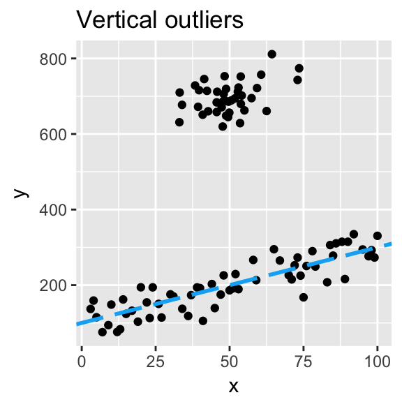

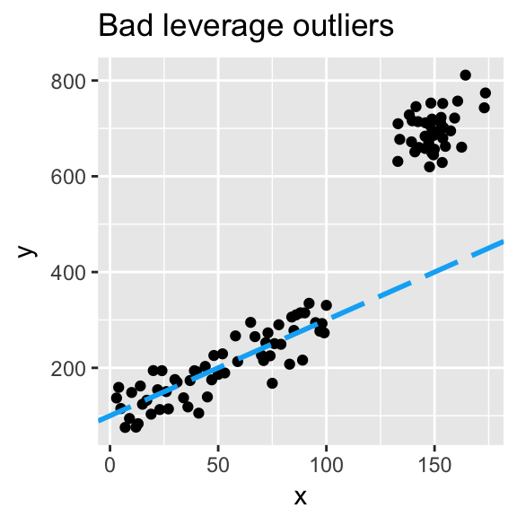

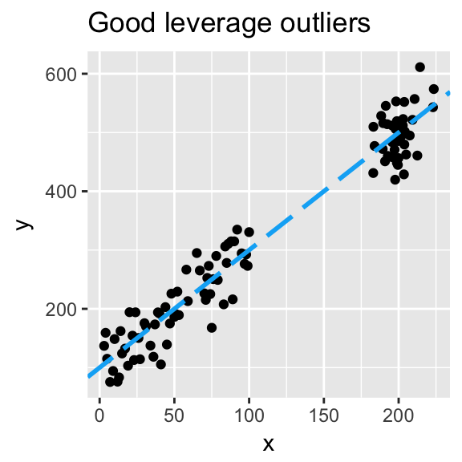

*Figure 1: Examples of type of outliers*

### Means

In the scenario of bad leverage outliers we observe that for OLS the mean of beta is already highly affected for 10 outliers. The bias also increases for OLS as the amount of outliers increase. The MM has good results for 10 outliers but performance decreases in the case of 20 outliers. In case of 30 and 40 outliers it is just as biased as OLS. The LTS has better performance than MM and OLS, for 40 outliers the bias has a large increases but is still better than OLS and MM. The DetMCD regression is again the most robust method and yields approximately equal means around 2.0 for all 4 contamination levels.

For good leverage OLS, LTS and MM display similar behavior. LTS is slightly more biased then OLS and MM for 10 outliers. DetMCD again has trouble when the contamination level is low but is also worse then all three other methods for 20, 30 and 40 outliers. DetMCD seems more affected by the good leverage outliers than LTS and MM.

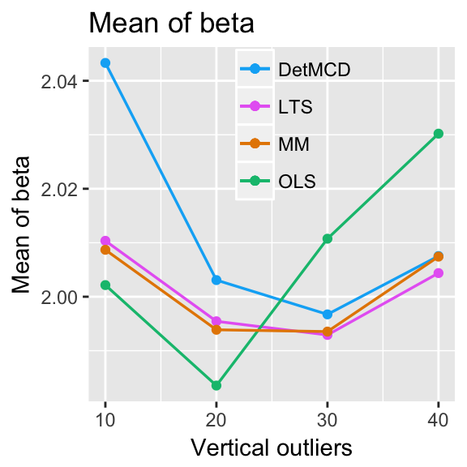

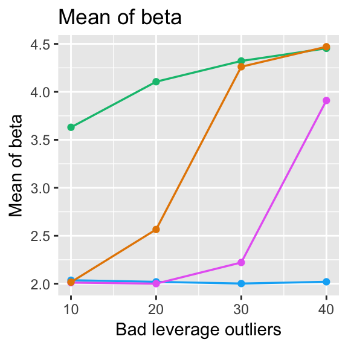

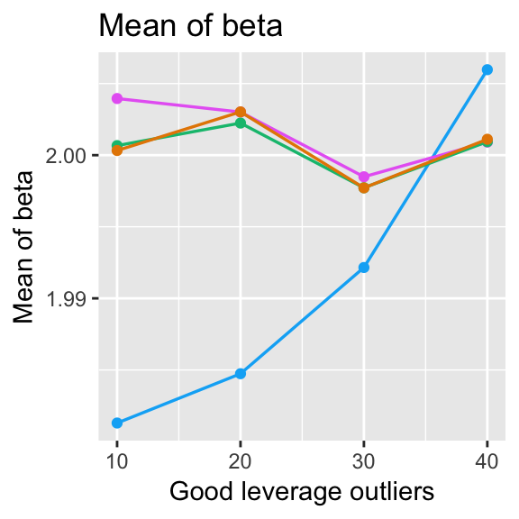

*Figure 2: Comparison of means for each method-outlier combination*

### Variances

In case of vertical outliers the estimated variance by LTS and MM are not much affected and show similar results. OLS displays inefficiency, especially when the level of contamination increases. On the contrary, DetMCD again has some trouble when then amount of outliers is small but gets more robust when more outliers are present. For 40 outliers the LTS, MM and DetMCD yield similar results.

In presence of bad leverage outliers the MM displays a large peak at 20 outliers. The LTS has comparable behavior for the variance as seen in the mean above. A deviation can be observed in the case of 30 outliers and then again a large increase in variance is seen for 40 outliers. The DetMCD again displays robust behavior for bad leverage outliers as also seen in the mean above. It yields an approximtely equal variance for all 4 contamination levels.

For good leverage outliers the LTS, MM and OLS yield similar results. DetMCD is not efficient, especially when level of contamination is small.

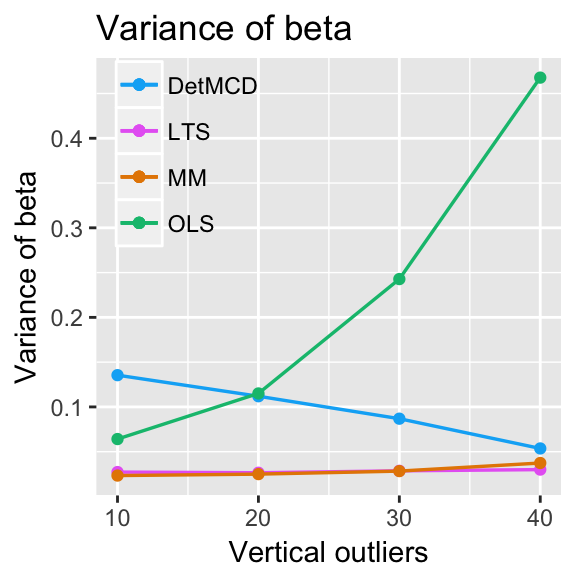

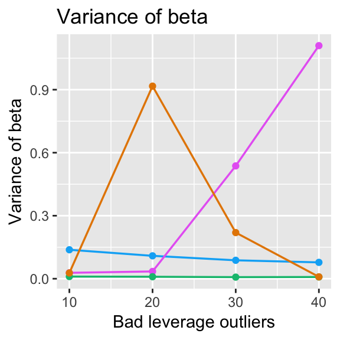

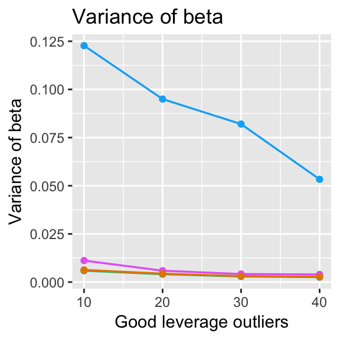

*Figure 3: Comparison of variance for each method-outlier combination*

### Computation Times

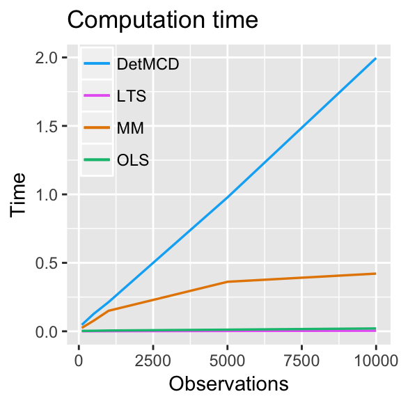

*Figure 4: Comparison of computation times*

### Conclusion

In presence of vertical outliers DetMCD has worse performance than LTS when contamination is small. For higher levels of contamination they yield more similar results. The LTS seems to use leverage points more often than DetMCD. If these outliers have good leverage the LTS has better performance than DetMCD. However, if these outliers have bad leverage the LTS is highly biased, especially for higher contamination levels. In contrast, the DetMCD displays robust behavior in presence of bad leverage outliers even when the level of contamination is high. This is in agreement with the statements in *Question 2*.

## **Question 4:**

```r
library(dplyr)
library(ggplot2)

load("TopGear.RData")
summary(TopGear)

# Do backward variable selection, as long as the BIC increases keep deleting the least significant variable

mm = lmrob(data=TopGear, formula = MPG ~ Fuel + Price + Cylinders + Displacement +
             DriveWheel + BHP + Torque + Acceleration + TopSpeed + Weight + Length + Width + Height +
             AdaptiveHeadlights + AdjustableSteering + AlarmSystem + Automatic + Bluetooth + ClimateControl +
             CruiseControl + ElectricSeats + Leather + ParkingSensors + PowerSteering + SatNav + ESP  + Origin )

print(mm$scale)
summary(mm)$coefficients[order(summary(mm)$coefficients[,4], decreasing=TRUE),]

# Removed ElectricSeats
mm = lmrob(data=TopGear, formula = MPG ~ Fuel + Price + Cylinders + Displacement +
             DriveWheel + BHP + Torque + Acceleration + TopSpeed + Weight + Length + Width + Height +
             AdaptiveHeadlights + AdjustableSteering + AlarmSystem + Automatic + Bluetooth + ClimateControl +
             CruiseControl + PowerSteering + Leather + ParkingSensors + SatNav + ESP  + Origin )

print(mm$scale)
summary(mm)$coefficients[order(summary(mm)$coefficients[,4], decreasing=TRUE),]

# Removed PwerSteering
mm = lmrob(data=TopGear, formula = MPG ~ Fuel + Price + Cylinders + Displacement +
             DriveWheel + BHP + Torque + Acceleration + TopSpeed + Weight + Length + Width + Height +
             AdaptiveHeadlights + AdjustableSteering + AlarmSystem + Automatic + Bluetooth + ClimateControl +
             CruiseControl  + Leather + ParkingSensors + SatNav + ESP  + Origin )

print(mm$scale)
summary(mm)$coefficients[order(summary(mm)$coefficients[,4], decreasing=TRUE),]

# Removed Origin
mm = lmrob(data=TopGear, formula = MPG ~ Fuel + Price + Cylinders + Displacement +
             DriveWheel + BHP + Torque + Acceleration + TopSpeed + Weight + Length + Width + Height +
             AdaptiveHeadlights + AdjustableSteering + AlarmSystem + Automatic + Bluetooth + ClimateControl +
             CruiseControl  + Leather + ParkingSensors + SatNav + ESP   )

print(mm$scale)
summary(mm)$coefficients[order(summary(mm)$coefficients[,4], decreasing=TRUE),]

# Removed ParkingSensor
mm = lmrob(data=TopGear, formula = MPG ~ Fuel + Price + Cylinders + Displacement +
             DriveWheel + BHP + Torque + Acceleration + TopSpeed + Weight + Length + Width + Height +
             AdaptiveHeadlights + AdjustableSteering + AlarmSystem + Automatic + Bluetooth + ClimateControl +
             CruiseControl  + Leather  + SatNav + ESP   )

print(mm$scale)
summary(mm)$coefficients[order(summary(mm)$coefficients[,4], decreasing=TRUE),]

# Removed Leather
mm = lmrob(data=TopGear, formula = MPG ~ Fuel + Price + Cylinders + Displacement +
             DriveWheel + BHP + Torque + Acceleration + TopSpeed + Weight + Length + Width + Height +
             AdaptiveHeadlights + AdjustableSteering + AlarmSystem + Automatic + Bluetooth + ClimateControl +
             CruiseControl  + SatNav + ESP   )

print(mm$scale)
summary(mm)$coefficients[order(summary(mm)$coefficients[,4], decreasing=TRUE),]

# Removed Automatic
mm = lmrob(data=TopGear, formula = MPG ~ Fuel + Price + Cylinders + Displacement +
             DriveWheel + BHP + Torque + Acceleration + TopSpeed + Weight + Length + Width + Height +
             AdaptiveHeadlights + AdjustableSteering + AlarmSystem  + Bluetooth + ClimateControl +
             CruiseControl  + SatNav + ESP   )

print(mm$scale)
summary(mm)$coefficients[order(summary(mm)$coefficients[,4], decreasing=TRUE),]

# Removed AdjustableSteering
mm = lmrob(data=TopGear, formula = MPG ~ Fuel + Price + Cylinders + Displacement +
             DriveWheel + BHP + Torque + Acceleration + TopSpeed + Weight + Length + Width + Height +
             AdaptiveHeadlights  + AlarmSystem  + Bluetooth + ClimateControl +
             CruiseControl  + SatNav + ESP   )

print(mm$scale)
summary(mm)$coefficients[order(summary(mm)$coefficients[,4], decreasing=TRUE),]

# Removed SatNav
mm = lmrob(data=TopGear, formula = MPG ~ Fuel + Price + Cylinders + Displacement +
             DriveWheel + BHP + Torque + Acceleration + TopSpeed + Weight + Length + Width + Height +
             AdaptiveHeadlights  + AlarmSystem  + Bluetooth + ClimateControl +
             CruiseControl + ESP   )

print(mm$scale)
summary(mm)$coefficients[order(summary(mm)$coefficients[,4], decreasing=TRUE),]

# Removed CruiseControl
mm = lmrob(data=TopGear, formula = MPG ~ Fuel + Price + Cylinders + Displacement +
             DriveWheel + BHP + Torque + Acceleration + TopSpeed + Weight + Length + Width + Height +
             AdaptiveHeadlights  + AlarmSystem  + Bluetooth + ClimateControl +
             ESP   )

print(mm$scale)
summary(mm)$coefficients[order(summary(mm)$coefficients[,4], decreasing=TRUE),]


# Removed DriveWheel
mm = lmrob(data=TopGear, formula = MPG ~ Fuel + Price + Cylinders + Displacement +
             BHP + Torque + Acceleration + TopSpeed + Weight + Length + Width + Height +
             AdaptiveHeadlights  + AlarmSystem  + Bluetooth + ClimateControl +
             ESP   )

print(mm$scale)
summary(mm)$coefficients[order(summary(mm)$coefficients[,4], decreasing=TRUE),]


# Removed Bluetooth
mm = lmrob(data=TopGear, formula = MPG ~ Fuel + Price + Cylinders + Displacement +
             BHP + Torque + Acceleration + TopSpeed + Weight + Length + Width + Height +
             AdaptiveHeadlights  + AlarmSystem + ClimateControl +
             ESP   )

print(mm$scale)
summary(mm)$coefficients[order(summary(mm)$coefficients[,4], decreasing=TRUE),]



# Removed ClimateControl
mm = lmrob(data=TopGear, formula = MPG ~ Fuel + Price + Cylinders + Displacement +
             BHP + Torque + Acceleration + TopSpeed + Weight + Length + Width + Height +
             AdaptiveHeadlights  + AlarmSystem  +
             ESP   )

print(mm$scale)
summary(mm)$coefficients[order(summary(mm)$coefficients[,4], decreasing=TRUE),]



# Removed AdaptiveHeadlights
mm = lmrob(data=TopGear, formula = MPG ~ Fuel + Price + Cylinders + Displacement +
             BHP + Torque + Acceleration + TopSpeed + Weight + Length + Width + Height +
             AlarmSystem  +
             ESP   )

print(mm$scale)
summary(mm)$coefficients[order(summary(mm)$coefficients[,4], decreasing=TRUE),]

# Removed Alarmsystem
mm = lmrob(data=TopGear, formula = MPG ~ Fuel + Price + Cylinders + Displacement +
             BHP + Torque + Acceleration + TopSpeed + Weight + Length + Width + Height + ESP   )

print(mm$scale)
summary(mm)$coefficients[order(summary(mm)$coefficients[,4], decreasing=TRUE),]


# Removed Price
mm = lmrob(data=TopGear, formula = MPG ~ Fuel+ Cylinders + Displacement +
             BHP + Torque + Acceleration + TopSpeed + Weight + Length + Width + Height + ESP   )

print(mm$scale)
summary(mm)$coefficients[order(summary(mm)$coefficients[,4], decreasing=TRUE),]

# Removed ESP
mm = lmrob(data=TopGear, formula = MPG ~ Fuel + Cylinders + Displacement +
             BHP + Torque + Acceleration + TopSpeed + Weight + Length + Width + Height   )

print(mm$scale)
summary(mm)$coefficients[order(summary(mm)$coefficients[,4], decreasing=TRUE),]


summary(mm)


# Do analysis
# Look at some other methods

TopGearSelection = TopGear %>%
  select(MPG, Fuel, Cylinders, Displacement, BHP,Torque, Acceleration, TopSpeed,
         Weight, Length, Width, Height) %>%
  mutate(Diesel = (Fuel=="Diesel")*1, Petrol = (Fuel=="Petrol")*1) %>% select(-Fuel)
TopGearSelection = cbind(TopGearSelection,MISSING = is.na(rowSums(TopGearSelection)) * 1)

xdat = TopGearSelection %>% filter(MISSING==0) %>% select(-MPG, -MISSING, -Petrol)
ydat = TopGearSelection %>% filter(MISSING==0) %>% select(MPG)
#apply our rubust ad-hoc estimator
xydat=cbind(xdat,ydat)
lmdetres  = lmDetMDC(x=xdat,
         y=ydat,
         h = 150)


ggplot(data=data.frame(fitted=lmdetres$fitted.values, true=ydat),
       aes(x=fitted, y=MPG)) + geom_point() + geom_abline(slope=1)

#withnames = data.frame(TopGearSelection, TopGear$Maker, TopGear$Type) %>% filter(MISSING==0)
#withnames = data.frame(withnames, resid=lmdetres$residuals$MPG)
#withnames
#print("The 10 largest outliers. Hybrids.... ofcourse")
#View(withnames)

#apply lts
lts=ltsReg(x=xdat[,-c(1,11)],y=ydat,intercept = TRUE,data=xydat)
ggplot(data=data.frame(fitted=lts$fitted.values, true=ydat), aes(x=fitted, y=MPG)) + geom_point() + geom_abline(slope=1)

#apply OLS
lm = lm(data=xydat, formula = MPG ~ Diesel + Cylinders + Displacement + BHP + Torque + Acceleration + TopSpeed + Weight + Length + Width + Height)
summary(lm)
ggplot(data=data.frame(fitted=lm$fitted.values, true=ydat), aes(x=fitted, y=MPG)) + geom_point() + geom_abline(slope=1)

#apply MM

mm = lmrob(data=xydat, formula = MPG ~ Diesel + Cylinders + Displacement + BHP + Torque + Acceleration + TopSpeed + Weight + Length + Width + Height)
summary(mm)
ggplot(data=data.frame(fitted=mm$fitted.values, true=ydat), aes(x=fitted, y=MPG)) + geom_point() + geom_abline(slope=1)

#split into test and training data set
n <-nrow(xydat)
data.perm <- xydat[ sample (n) ,]
ntrain <-round (.9* nrow ( xydat ))
data.train <-data.perm [1: ntrain ,]
data.test <-data.perm [( ntrain +1): nrow ( xydat ) ,]
y.train <-data.train$MPG
y.test <-data.test$MPG
x.train <-data.train[,-12]
x.test <-data.test[,-12]
#predict with our estimator
lmdetres  = lmDetMDC(x=x.train, y=y.train, h = 150)
lmdetres$coefficients
alpha=lmdetres$coefficients[1]
beta=lmdetres$coefficients[-1]
pred.lmdetres= alpha+ as.matrix(x.test)%*%beta
ggplot(data=data.frame(fitted=pred.lmdetres, true=y.test),
       aes(x=pred.lmdetres, y=y.test)) + geom_point()
tukeyChi(pred.lmdetres,cc=1.55)
mad.detmcd = mad((pred.lmdetres-y.test), constant = 1.4826, na.rm = FALSE)
mae.detmcd = mean(abs(pred.lmdetres-y.test))

#predict wiht OLS-estimator
lm = lm(data=data.train, formula = MPG ~ Diesel + Cylinders + Displacement +
          BHP + Torque + Acceleration + TopSpeed + Weight + Length + Width + Height)
pred.ols=predict(lm,newdata=data.test)
plot(pred.ols,y.test)
ggplot(data=data.frame(fitted=pred.ols, true=y.test),
       aes(x=pred.ols, y=y.test)) + geom_point()
mad.ols = mad((pred.ols-y.test), constant = 1.4826, na.rm = FALSE)
mae.ols = mean(abs(pred.ols-y.test))


#predict with MM-estimator
mm = lmrob(data=data.train, formula = MPG ~ Diesel + Cylinders + Displacement +
             BHP + Torque + Acceleration + TopSpeed + Weight + Length + Width + Height)
pred.mm=predict(mm,newdata = data.test)
ggplot(data=data.frame(fitted=pred.mm, true=y.test),
       aes(x=pred.mm, y=y.test)) + geom_point()
mad.mm = mad((pred.mm-y.test), constant = 1.4826, na.rm = FALSE)
mae.mm = mean(abs(pred.mm-y.test))


#predict with LTS-estimator
lts=ltsReg(x=x.train[,-c(1,11)],y=y.train,intercept = TRUE,data=data.train)
lts$coefficients
alpha=lts$coefficients[1]
beta=as.numeric(lts$coefficients[-1])
pred.lts= alpha + ( as.matrix(x.test[,-c(1,11)]) %*% ((beta)) )
ggplot(data=data.frame(fitted=pred.lts, true=y.test), aes(x=pred.lts, y=y.test)) +
  geom_point()
mad.lts = mad((pred.lts-y.test), constant = 1.4826, na.rm = FALSE)
mae.lts = mean(abs(pred.lts-y.test))
```

All coefficient interpretations below are in the case of keeping all other variables fixed. First, we apply OLS on the reduced data. The power, torque of the engine and the weight and width of the car have a positive influence on MPG. The petrol, amount of cylinders, displacement, acceleration, maximum speed, length and height have a negative influence on the MPG. Some of these results are counterintuitive. For example, on average we do not expect a heavier car to be more fuel efficient. The plot also shows OLS fails to estimate a proper regression fit due to the presence of the high MPG observations. The regression line is clearly leveraged upwards resulting in a bias.

Secondly, we apply the robust MM-estimator. The cylinders, acceleration and length have positive influence on MPG. Petrol, displacement, power, maximum speed, weight, height and width have a negative influence. The variables power and width now have a negative influence on MPG as we would expect. In agreement, the plot displays more robust behavior than OLS. The high MPG observations do not have a signifcant influence on the regression line and a good fit to the values is observed.

Thirdly, we apply the robust LTS estimator. The LTS cannot handle discrete variables therefore we remove the following variables: amount of cylinders and type of fuel. The torque, acceleration and maximum speed have positive influence on the MPG. The displacement, power, weight, height and width have negative influence on the MPG.

Lastly, we apply the deterministic MCD estimator. We use a subset h equal to 150 observations. The plot displays better performance than OLS but seems to fit worse than the LTS and MM. The torque, acceleration, maximum speed, weight, length, width, height have a positive influence on the MPG. The cylinders, displacement, power and petrol have a negative influence. Again some of these results are not as expected.

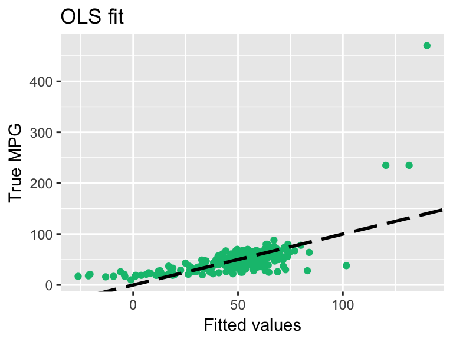

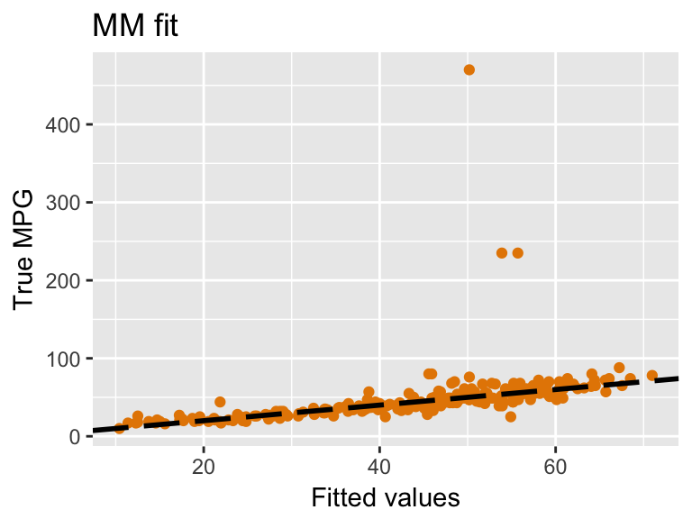

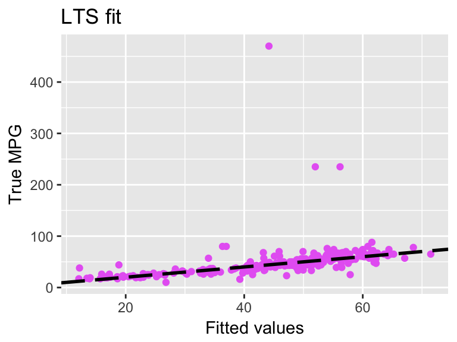

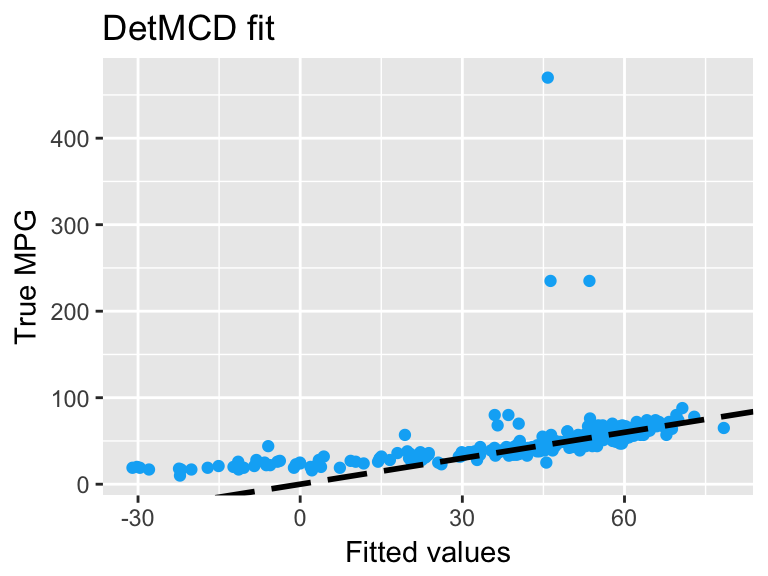

*Figure 5: Comparison of fit for each method*

Next we split the data into a 10% test and a 90% training set and then the four regression methods are applied on the training set. Consequently, prediction performance is compared using the test set.

Comparing the results we can see the LTS and MM estimator appears to obtain te best predictions, with few but some extreme vertical outliers. This confirms our results from the in question 3 which states that the LTS and MM perform better than detMCD and OLS in case of low contamination levels.

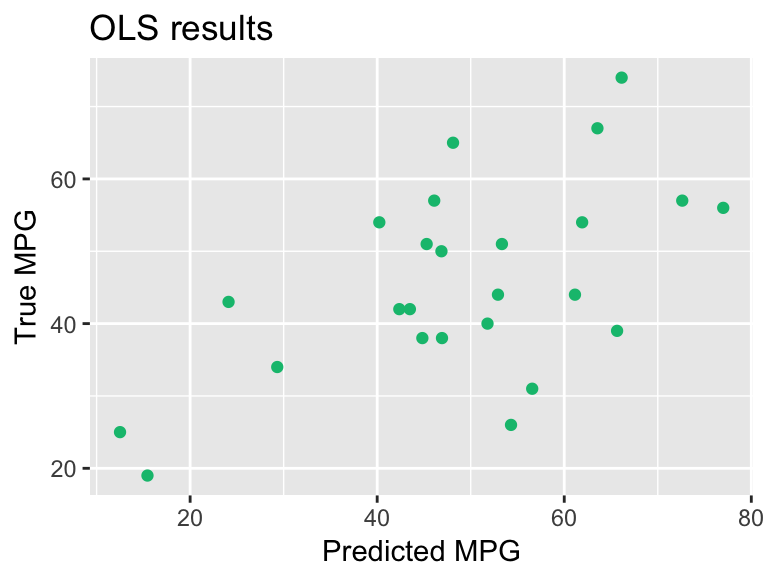

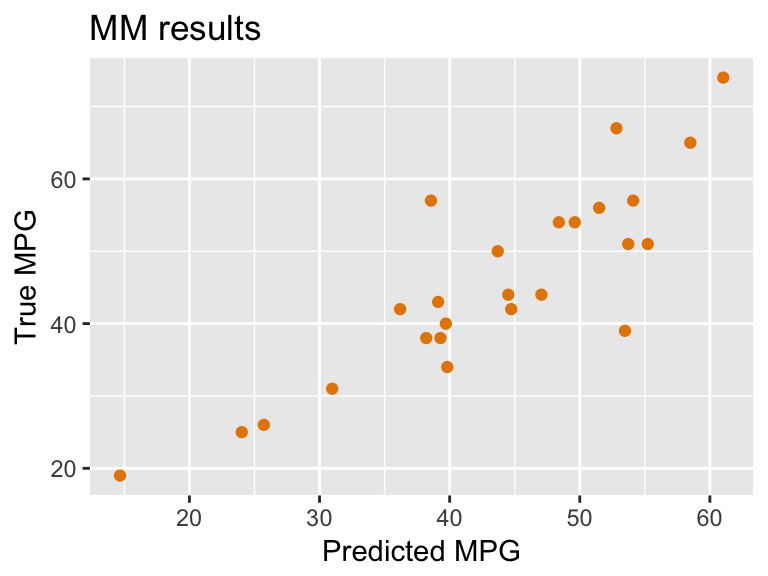

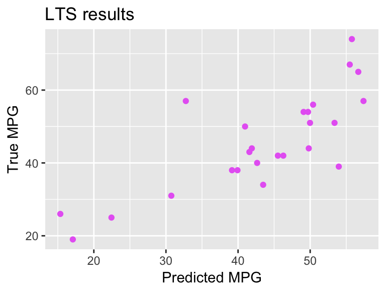

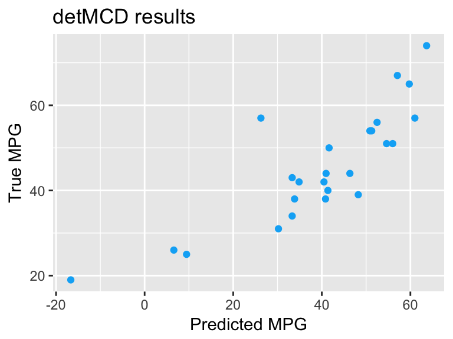

*Figure 6: Predicted vs true for each method*

In order to evaluate the predictive performance of the four regression estimators the Mean Squared Prediction Error (MSPE) is not suitable for this data set. We have some severe outlying observations resulting in large residuals. These outliers will have a large influence on the MSPE as these would be penalized very hard by squaring the error. As these outliers now have large effect the MSPE is not robust in this case. A better metric is for example the Mean Absolute Deviation (MAD). *Table 2* below displays a comparison of several accuracy metrics for the methods.

*Table 2: Accuracy metric comparison*

| Method | MSPE | MAE | MAD |
| --- | --- | --- | --- |
| **OLS** | 192.69517 | 11.369007 | 13.877779 |
| **MM** | 49.07866 | 5.056864 | 5.477566 |
| **LTS** | 72.16421 | 6.103593 | 6.035432 |
| **detMCD** | 139.90984 | 8.002646 | 8.132842 |